The present study investigates the production and perception of segments in words in a language by bilinguals that they do not yet know, specifically, French or German. In so doing, the present dissertation aims to investigate the very initial stage of L3 phonological acquisition acquisition by providing an overview of the initial relative influence of both L1 and L2. In this study, late Spanish-English bilinguals of both order of acquisition will be given an aspirating L3 (German) and a true-voicing L3 (French) to shadow. In perception, the participants will match L3 vowel sounds to L1 and L2 categories, and complete an AX discrimination task. Following these tasks, the link between perception and production will be analyzed and discussed.

# Research Questions

The present dissertation is guided by the following research questions. Broadly, this project focuses on the influence of the L1 and L2 system on L3 perception and production, and how cross-linguistic similarity might predict this influence. By taking these factors into account, more precise evidence can be provided to evaluate the predictions of L3 models. The following section introduces a total of 7 research questions that will be covered over three total chapters. In each subsection, a research question will be introduced, followed by hypotheses and predictions, as well as additional possible outcomes and their interpretations.

## Chapter 2: Production

RQ1: Will Spanish-English bilinguals produce L3 words with Spanish or English like VOT?

Based on the results of [@parrish_relative_2021], in which L3 VOT was found to fall between L1 and L2, it is predicted that these participants’ L3 VOT will also fall between L1 and L2 values in both L3 German and L3 French. This result would support the Linguistic Proximity Model, which suggests that L3 learning is a case of co-activation of the L1 and the L2. However, there are several other possible scenarios that would support other L3 models. If L3 VOT values are practically equivalent to L1 or L2 values, the Typological Primacy Model would be supported, since single language influence would be a plausible explanation of this result. If L3 VOT is also target like, and it practically equivalent to L1 or L2 VOT, then the Cumulative Enhancement Model and Scalpel Model could also explain the results. On the other hand, if L3 VOT is practically equivalent to L2 VOT, this result is not (always) facilitative, and mirror image groups with distinct L2s both show L2-like L3 VOT, the L2 Status Factor would be the only model capable of explaining the data.

Additionally, there are no specific predictions about whether each L3 segment will be influenced to a similar degree, or whether some segments will be more influenced by the L1 or L2 than others. The results of [@parrish_relative_2021] suggest that each segment was similarly influenced by the L1 and L2, but there was some variation. In terms of L3 models, again the LPM would be the only model that could account for variation in the activation of both languages across segments in which both L1 and L2 influence can be seen. If some segments were L1 like and others were L2 like, then the CEM, Scalpel Model, and LPM could account for this, where TPM the L2SF could not.

RQ2: Will Spanish-English bilinguals produce vowels more like English or Spanish?

The predictions in vowel production are analogous to those in stop production. It is predicted that L3 vowel production will be intermediate between L1 and L2 values. The evidence in support of L3 models and their predictions is also identical in the case of vowels. That is, full transfer models (TPM, L2SF) predict that each segment should be equally affected by the same source language, either the L2 (L2SF) or the closest typological language (TPM). Full transfer models would be supported in L3 production and perception were found to be practically equivalent to either the L1 or the L2 Partial transfer models (LPM, the Scalpel Model) suggest that production and perception L3 vowels are influenced by both the L1 and the L2 and that performance on experimental tasks of L3 vowels should fall between L1 and L2 performance.

RQ3: Will the same CLI trends be observed in L3 German as L3 French in production?

It is predicted that the phonetic differences in the input will affect the performance in the shadowing task, at least at the group level. In @parrish_relative_2021, L1 Spanish-L2 English bilinguals shadowed French, which is phonetically similar to Spanish in its use of VOT to distinguish stop consonants. As a result, the French stimuli were unaspirated short lag stops. The group results, however, revealed that many participants aspirated word initial stops, presumably due to the influence of L2 English. This result suggested that L2 influence is frequent and pronounced in some participants. However, other participants produced target-like L3 French tokens. In this latter case, it was unclear whether L3 productions were target-like due to effective mimicry or language influence. By including a German L3 group, both explanations can be tested. If, between groups with the same order of acquisition, relative VOT of shadowed German tokens are practically equivalent to the relative VOT of shadowed French and they are not target-like, then the phonetics of the stimuli will not seem to be a contributing factor to L3 pronunciation. That is, for example, if L1 Spanish-L2 English speakers aspirate German and French at the same rates, despite the German tokens being aspirated and French tokens being unaspirated, then the aspiration of the input would not reliably predict L3 production patterns. If, on the other hand, L3 German VOT is aspirated more often than L3 French, it could be interpreted as evidence that the phonetic qualities of the input at first exposure to an L3 interact with language status effects. A third possibility is that typological similarity of segments is the most influential factor predicting L3 pronunciation at first exposure. In order for this view to be supported, close to target-like L3 production should be seen from both orders of acquisition. For example, if the L3 were French and if typological (acoustic) similarity was the most influential predictor, it would be expected for L1 Spanish-L2 English and L1 English-L2 Spanish speakers to produce L3 French as close to their own Spanish, whether or not it is the L2.

RQ4: Will primary influence of the L1 or L2 remain consistent in vowels and stops?

Generalization across segments in an important piece of evidence to evaluate the predictions of full transfer models in L3A, since it provides evidence for or against holistic influence. In particular, if stop categories are influenced by a specific language, then full transfer models, such as the TPM and L2SF would predict that vowel categories should be influenced by the same language. Alternatively, if stops and vowels are influenced by different languages known by the L3 learner, then this would falsify the predictions of full transfer models.

## Chapter 3: Perception

RQ5: Will bilinguals categorize L3 vowel sounds using L1 and L2 categories?

A closely related question to generalization across L3 segments is whether the same sounds will be perceived and categorized using a single language’s categories, or whether the same sound may be assigned to an L1 category in one instance, but an L2 category in another. If the same sound is categorized differently by the same speaker, and if those categorizations are both L1 and L2 categories, then this will be taken as evidence of uncertainty, and access to both languages in the event of this uncertainty. The predictions of L3 models would likely be the same in this case as the categorization of different sounds in L1 and L2 categories.

RQ6: Is language specific discrimination fully accessible in L3 words?

In addition to categorization, the present dissertation will test whether language specific perceptual discrimination is accessible during the first encounter to a third language. Such information is useful in examining whether potential issues in L3 perception is due to difficulty in auditory discrimination or whether language mode effects may be a more appropriate explanation for potential non-target like categorization of L3 sounds. That is, if the participants categorize L3 sounds to L2 sounds when an L1 sound is more acoustically similar, but they still are able to discriminate fine phonetic distinctions, then it could be plausible that L2 mode effects, rather than lack of discrimination, contribute to L3 categorization.

## Chapter 4: Production and Perception

RQ7: Will the relative influence of a particular language perception match production?

It is unclear whether L3 models would predict that L3 perception and production develop in tandem, or whether perception should develop prior to production. Similarly to generalization, the link between perception and production can give information about how third language phonological acquisition may begin in terms of previous language influence. That is, the present dissertation will gather data that will shed light on not only whether single language influence affects all segments, but also whether this influence is distinct in perception and production. Currently, the predictions of L3 models are not well equipped to handle potential differences in perception and production. As a result, the outcome of the relationship between L3 perception and production will can only be evaluated by these models post-hoc.

# Method

## Participants

4 total groups of participants will take part in each experiment, in what @westergaard_crosslinguistic_2017 refers to as a fully combined design. There will be 2 bilingual groups with opposite orders of acquisition, Spanish L1-English L2, and English L1-Spanish L2, with each of these groups hearing either L3 German and L3 French, and 2 monolingual English and monolingual Spanish groups, who also both shadow French or German. German and French were chosen as the third languages primarily due to the phonetic differences in voice-onset time, where French is a true-voicing language (like Spanish) and German is an aspirating language (like English). Additionally, German and English and French and Spanish are typologically related in a global sense (i.e., not necessarily on a structure by structure basis). As a result, the present design will allow for the examination of language status effects, global typology effects, and structure by structure similarity effects. By doing so, the relative influence of each of these factors can be determined in these populations, and the evaluation of L3 model predictions can be carried out. Based on a power analysis carried out in [@parrish_relative_2021], the bilingual groups will contain 75 participants per group, where the monolingual groups will contain 50 participants per group, for a total of 250 participants.

## Materials

Each participant will produce stop-initial tokens in each language that they speak, and shadow tokens in both L3s (French and German). In the case of the bilingual groups, this involves both a Spanish and English word reading task, where the monolingual groups will only complete the word reading task in their L1. Additionally, bilinguals participants will complete the LexTALE proficiency test in their L2 [@izura_lexical_2016; @lemhofer_introducing_2012], and the Bilingual Language Profile to gather biographical information.

### Bilingual Language Profile

To measure language use and language dominance, the Bilingual Language Profile (BLP) [@birdsong_bilingual_2012] will be used. The BLP is a self-report questionnaire which was designed to measure language dominance. The questionnaire asks several questions related to language use, attitudes, and age of acquisition in bilinguals. The answers are scales that include Likert scale, discrete numbers of years, and percentages of language use. The BLP can be administered online and was chosen for its comprehensiveness while also taking around 10 minutes to complete.

### LexTALE

The LexTALE [@izura_lexical_2016; @lemhofer_lexical_2016] will be used to measure English and Spanish proficiency. The LexTALE is a lexical decision task, in which participants see either words or pseudowords on a screen one at a time. Participants are supposed to then decide whether the word presented is a real word in the language or a pseudoword. The task is intended to be a measure of vocabulary size, which has been argued to correlate to language proficiency. Either the English and Spanish versions of the task will be used in the study, depending upon the L2 of participant.

### Stimuli

The following conditions will be tested in the body of the present dissertation in both perception and production. The predictions in Figure 3.1 are those that would support the idea that cross linguistic acoustic similarity drives CLI patterns in L3A. Additionally, these broad predictions serve for both perception and production, since there is little evidence that suggests that these L3A CLI patterns are distinct. In Chapter 2, these L3 conditions will be produced in shadowing tasks, where the chosen words for each condition will be recorded by native speakers and embedded in an online experiment for participants to listen to and repeat. In Chapter 3, the perception, involving both categorization and discrimination, of these conditions will be examined. As a result, the predictions here will be evaluated separately for production (chapter 2) and perception (chapter 3), while evaluating the link between perception and production will be covered in Chapter 4.

The conditions were designed to examine the relative impact of cross-linguistic acoustic similarity of stops and vowels on the production and perception of stops and vowels. Condition 1 aims to avoid acoustic bias and uses a vowel sound, /i/, which is present in both English and Spanish, together with a fricative word onset /f/. In contrast, condition 2 uses a voiceless stop initial /p/, together with /i/, to investigate whether L3 French tokens and L3 German tokens are produced as similarly to their respective references. Condition 3 introduces a conflict, in which the Spanish vowel /o/ is paired with an aspirated /p/ in L3 German. In theory, these bilinguals have access to language specific phonemes which include the Spanish-like /o/, aspirated /p/ and unaspirated /p/, but it is unclear whether access to Spanish and English phonemes is possible within the same L3 word. By examining and comparing L3 productions in condition 3, insight can be gained as to whether two language specific acoustic cues can be produced as target-like in the event that they are distinct and when they are the same. Condition 5 investigates an analogous circumstance, but uses an English-like vowel. Conditions 7 and 8 use a vowel not found in either English or Spanish, with a VOT bias (condition 7), and with a fricative (condition 8). If within-word acoustics influence the categorization of sounds within that word, then the vowel in these conditions should be produced distinctly in condition 7, but similarly in condition 8.

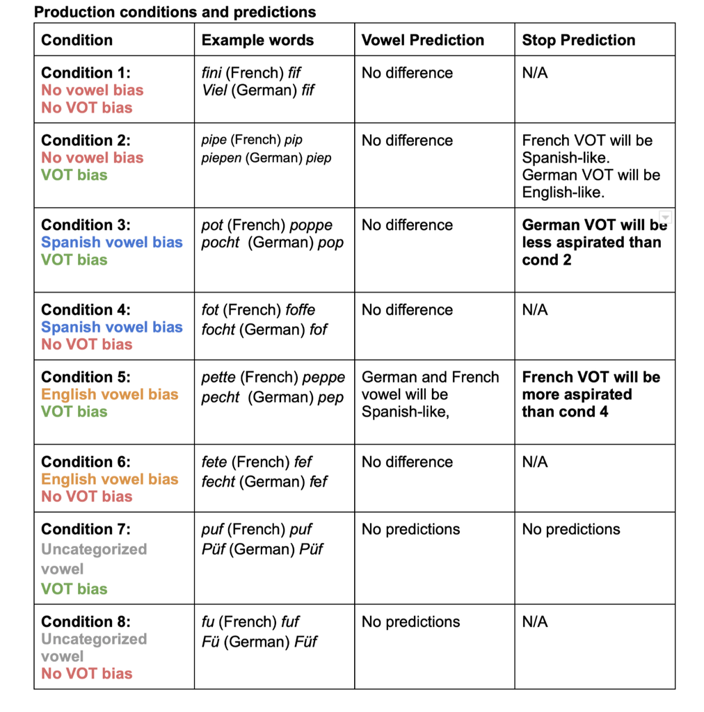

Vowel and stop conditions and predictions

### Chapter 2: Shadowing Task

The shadowing task is designed to elicit productions of L3 words at first exposure. This task is the same as the shadowing task in @parrish_relative_2021, but the word list has been updated and an L3 German block will be included During the task, the participants will see an orthographic representation of a word that they will shadow and they will play a recording of that word produced by a native speaker. Then, on the same screen, the participant will record themselves repeating the word they just listened to by clicking a button to record, and the same button to stop recording. The participants will be able to listen to their recording, and then will click a separate button to submit their recording. The shadowing task will be programmed in Labvanced [@finger_labvanced_2016].

### Chapter 2: Word Reading Tasks

Together with the shadowing task, the word reading tasks will be used to elicit L1 and L2 productions in order to make within-speaker comparisons between L1, L2 and L3. The word reading task be similar to the shadowing task, and is also replication of the method in @parrish_relative_2021. In these tasks, words will be presented on the screen in isolation and orthographically. Participants will record themselves reading the word aloud and will be able to listen to their recording prior to submission. The stimuli in the word reading tasks will be similar cross-linguistic matches to the words used in the shadowing task. Specifically, voiceless stop-initial words will be used in all three places of articulation in one and two syllable words. All three places of articulation, as well as fricative initial stimuli, will be paired with high low and mid vowels. The word reading tasks will be programmed in Labvanced [@finger_labvanced_2016].

### Chapter 2: Procedure

Participants will complete the experimental tasks in a semi-longitudinal fashion, in which each participant will complete 1 of 4 language specific blocks on different dates. Data collection will take place online and participants will be recruited using the online platform Prolific.co. Every potential participant will first complete a screening block, in which they will take the LexTALE [@izura_lexical_2016; @lemhofer_lexical_2016] in their L2 and the Bilingual Language Profile [@birdsong_bilingual_2012]. Exclusion criteria will include a LexTALE score under 50% correct or knowledge of a third language. Once participants are eligible for the experimental tasks, they will begin with either L3, followed by the L1 or L2 in a counterbalanced manner. The blocks will begin with the production task, either a shadowing task (L3) or a word reading task (L1 and L2). Then, in the same experiment, the participant will complete the phoneme categorization task followed by the AX discrimination tasks. In order to control for potential language mode effects brought on by the experiment, the language specific blocks will be given of separate days. Instructions will be given in each block in the participant’s native language, either English or Spanish.

### Chapter 2: Analysis

In the production tasks, both vowel and stop production will be analyzed using Bayesian Multilevel regression models. In the case of stops, Voice Onset Time will be modeled as a function of language, consonant frame, LexTALE score, and a continuous dominance measure obtained from the BLP. Random intercepts will include words and participants. In vowel production, F1 and F2 will be modeled separately using the same predictors as the stop model. A region of practical equivalence (ROPE) will also be established to determine whether any differences in productions between two languages can be attributed to noise in the data, and provide evidence that two specific languages are being produced in a near-equivalent manner. Such evidence would entail the entire posterior distribution falling within the equivalence bounds.

### Chapter 3: Perception

In order to examine perception of vowels, a phoneme categorization task will be carried out in both German and French in separate sessions on different days. During this task, participants will hear tokens produced by L1 German or French speakers, in which a vowel sound is embedded in a consonant frame and choose which English or Spanish sound that best matches the sound that they heard. The English and Spanish sounds will be presented orthographically on a screen in carrier words. One at a time, a stimulus sound will be played and the participant will choose its closest match by clicking on the English or Spanish word on screen. Following their selection, the participants will rate how closely the sound they heard matches the selection that they chose by clicking a slider scale. The scale ranges from 1-7, but the selection is any point on the scale, thus rendering a continuous rating.

The stimulus sounds will be similar to the vowel sounds in the production sentences, and are listed in figure 3.2. The vowel sounds will be presented in two distinct consonant frames per language: a fricative frame (/fvf/) and a voiceless bilabial obstruent frame (/pVp/). These frames were chosen due to the similarity between German and English versus and Spanish and French bilabial stops, which are similar to one another. By including a bilabial frame, it is possible to determine whether language specific acoustic cues bias the categorization of the vowel sound to L1 or L2 categories. For example, in the case of the vowel sound /i/, which is present in both English and Spanish, if the bilabial consonant frame matters for vowel categorization, then the German frame should result in more selections of English categories, and the French frame should result in more selections of Spanish categories when the vowel sound is present in both English and Spanish. On the other hand, the fricative frame allows for the examination of selections when no or vowel only acoustic bias present. The experiment will be programmed in Psychopy [@peirce_psychopy2_2019].

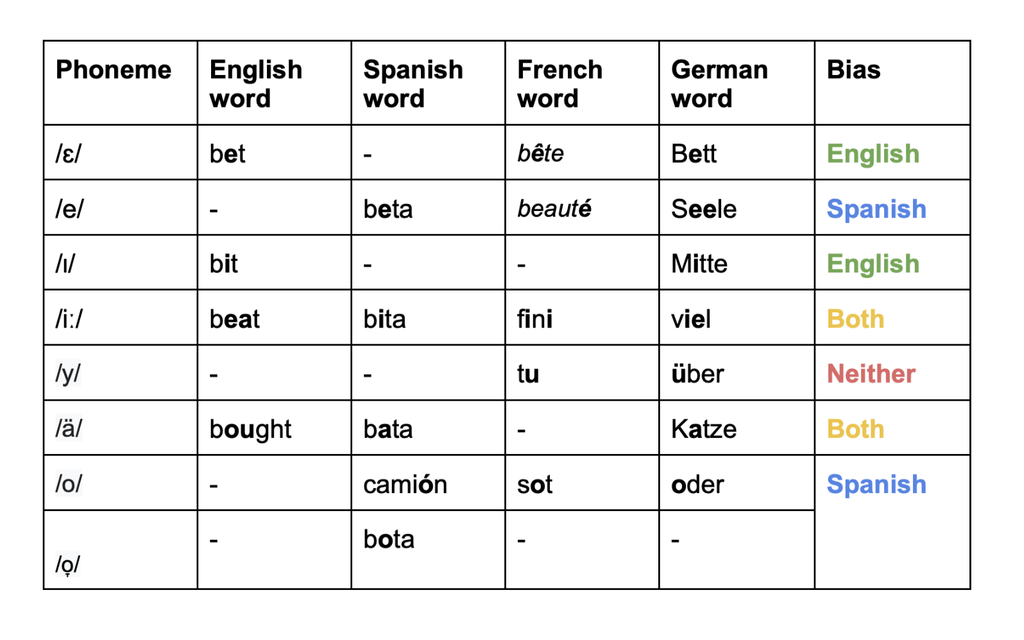

Perception Conditions

In terms of discrimination, the present dissertation will focus on English vowel contrasts using an AX discrimination task. In particular, the discrimination task is designed to determine whether L3 learners have access to perceptual discrimination present in either their L1 or L2, or whether order of acquisition of languages may impact phonetic discrimination ability. In the AX discrimination task, the participants will hear a sequence of two words drawn from a *sheep-ship* like continuum in 2 language-specific (French and German) blocks and decide whether those words sound the same or different. The continua will be created by using the tokens from the German and French L1 speakers productions of the vowels in both consonant frames made for the phoneme categorization task and resynthesizing them using a Praat script. In addition, a second set of continua, using a *pat-pot* like continuum, will be created though this contrast is not present in French or German, to further test whether English vowel contrasts are accessible in L3 sounds. The continua will be purely spectral, and duration will be held constant. In each 7 step continuum, all 49 possible combinations of sound will be presented a total of three times each, resulting in 147 repetitions per continuum per participant. Each continuum will be created by resynthesizing L1 French and German informant speech using a PRAAT scripts. The task will be programmed in Psychopy [@peirce_psychopy2_2019].

### Chapter 3: Procedure

The procedure for chapter 3 is included in the procedure for chapter 2. That is, perception and production tasks will be given in four language specific blocks on different days, following a screening block. Instructions will be given in the L1 of the participant, either English or Spanish, during each block.

### Chapter 3: Analysis

Phoneme categorization will be analyzed in a descriptive manner. Specifically, it will show the preferred category per condition per language, and its goodness ratings. This data will be visualized and used in comparison to both production and discrimination data. The AX discrimination task will again use Bayesian linear regression to model correctness as a function of language, consonant frame, LexTALE score, and dominance, with random intercepts per participant and item.

# Timeline

The timeline to completion starts with obtaining IRB approval, followed by experiment creation, data collection, data analysis, and finally with writing the results and discussion potions of the dissertation. Here, I propose a timeline for the completion of each step, including allowing time for feedback, up until a defense date in May 2023. Following the defense of this proposal and implementation of the committee’s recommendations in late January, the IRB will be submitted for review by mid-February. While awaiting IRB approval, the experiments will be created in which stimuli are created and L1 German and French informants will provide audio for re-synthesis in perception experiments and shadowing in production experiments. Once IRB approval is obtained and the experiments are created, data collection will begin in mid-April and take place over the summer, with the goal of being completed by early September, 2022. Once all data has been collected, analysis and writing writing will begin in early September with the goal of being finished by mid-Spring 2023 (March). Following the completed dissertation draft, editing and revisions will be carried out and a final draft will be sent to the committee for review in April 2023 at least one month prior to a defense date in May 2023.